# Data Cleaning and Visualization with American Community Survey Data Set

Afrida Masud

2023-08-18

# Goal of the Project:

This project’s goal is to explore the American Community Survey (ACS) dataset. The USA Census Bureau publishes this dataset every year. The ACS data comprises a multitude of demographic, economic, personal, and household data relating to individuals. To learn more about this data set visit “https://www.census.gov/programs-surveys/acs”.

I will do the following-

1. Create a histogram of Salary income past 12 months for Civilian Employed, at work
2. Create a table that reports the median, mean of “Wages or salary income past 12 months” for different categories
3. Create a bar graph for the median income of each category
4. Show the Relationship between age and income for working-age individuals through a scatter plot

## Downloading and Loading the dataset in R

**Getting the list of files from the URL:** You can manually achieve this by visiting the website, locating the specific file, and then downloading it to the working directory. I prefer to access the files directly from R Markdown. This way, if I decide to switch to a different dataset, I can download it from within R, eliminating the need to repeat the manual process. By utilizing the view function to examine the links, you’ll notice that the files primarily come in the form of zip files. Links[zipfiles] will show the name of the zip files. I commented it out as the list is long. The next logical step would involve extracting a list of these zip files.

```r
setwd("C:/Users/USER/OneDrive - IL State University/Micro with R")
library(rvest)
library(httr)
library(XML)
library(tidyverse)
library(tidyr)
library(dplyr)
library(ggplot2)
library(scales)
library(officer)
library(RColorBrewer)
library(rlang)


theme_set(theme_bw(16))
url <- "https://www2.census.gov/programs-surveys/acs/data/pums/2021/1-Year/"
pAGEPContent <- readLines(url)
Links <- getHTMLLinks(pAGEPContent)
view(Links)
zipFiles <- grep("\\.zip", Links)
#Links[zipFiles]
```

**Downloading the desired Zip File:** I’ll be utilizing personal-level data from North Carolina State. But feel free to substitute any other state’s data of your preference. From the list “csv_pnc.zip” is the data of interest. Here, “p” refers to the personal level, and “NC” refers to North Carolina. The following code helps download the zip file and extract its contents into my designated directory.

```r
download.file("https://www2.census.gov/programs-surveys/acs/data/pums/2021/1-Year/csv_pnc.zip", "csv_pnc.zip")
unzip("csv_pnc.zip")
```

**Loading the Dataset into R:** With the provided code snippet, you can see the name of the Excel file extracted from the previous step, all from within R. This process eliminates the need to exit R. Assuming there are no other Excel files present in your working directory, you will solely encounter the “psam_p37.csv” file in your directory.

```r
print(list.files(pattern = "\\.xlsx$|\\.xls$|\\.csv$"))
```

```
## [1] "psam_p37.csv"
```

```r
data <- read.csv("psam_p37.csv")
save(data, file = "main.Rdta")
# load("main.Rdata")
# View(data)
```

After loading the data set into R, we can begin executing our objectives.

## Goal 1 : Create a histogram of Salary income past 12 months for Civilian Employed, at work

ACS data set comes with a data dictionary that can be found at “https://www2.census.gov/programs-surveys/acs/tech_docs/pums/data_dict/PUMS_Data_Dictionary_2021.pdf”. We need wage and employment data to create a histogram of Salary income for civilian employed at work, From the data dictionary, we can see that ESR=1 is Civilian employed. The “WAGP” variable contains salary income information.

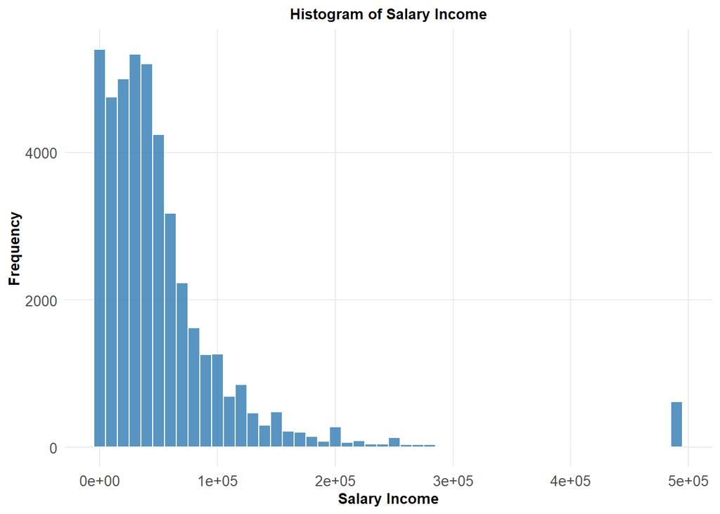

```r
filtered_data <- subset(data, ESR == 1, select = WAGP)
#Histogram with ggplot
ggplot(filtered_data, aes(x = WAGP)) +
  geom_histogram(binwidth = 10000, fill = "#2e7bb4", color = "#FFFFFF", alpha = 0.8) +
  labs(x = "Salary Income", y = "Frequency") +
  ggtitle("Histogram of Salary Income") +
  theme_minimal() +
  theme(plot.title = element_text(size = 10, face = "bold", hjust=.5),
        axis.text = element_text(size = 10 ,margin = margin(0, 0, 0, 0)),
        axis.title = element_text(size = 10, face = "bold"),
        # panel.grid.major = element_blank(),
        panel.grid.minor = element_blank())
```

```r
        # panel.border = element_rect(colour = "black",fill=NA, linewidth  =.5))
```

## Goal 2 : Create a table that reports the median, mean of “Wages or salary income past 12 months” for different categories:

In this section, I will create a table with the median and mean of salary for the following subgroups. The table will also include a column with the number of observations for each group.

- Age 18-64 (i.e., “working age”)
- Age 18-64 & male
- Age 18-64 & female
- Age 18-64 with a college degree
- Age 18-64 with a college degree in Economics

```r
# Filter the data for each subgroup and calculate the median, mean, and count
AGEP_group <- data %>%
  filter(AGEP >= 18 & AGEP <= 64) %>%
  summarize(Median = median(WAGP, na.rm = TRUE),
            Mean = mean(WAGP, na.rm = TRUE),
            Count = n())

SEX_group <- data %>%
  filter(AGEP >= 18 & AGEP <= 64, SEX == 1) %>%
  summarize(Median = median(WAGP, na.rm = TRUE),
            Mean = mean(WAGP, na.rm = TRUE),
            Count = n())

female_group <- data %>%
  filter(AGEP >= 18 & AGEP <= 64, SEX == 2) %>%
  summarize(Median = median(WAGP, na.rm = TRUE),
            Mean = mean(WAGP, na.rm = TRUE),
            Count = n())

college_group <- data %>%
  filter(AGEP >= 18 & AGEP <= 64, SCHL >= 20 & SCHL <= 21) %>%
  summarize(Median = median(WAGP, na.rm = TRUE),
            Mean = mean(WAGP, na.rm = TRUE),
            Count = n())

economics_group <- data %>%
  filter(AGEP >= 18 & AGEP <= 64, SCHL >= 20 & SCHL <= 21, FOD1P== 5501) %>%
  summarize(Median = median(WAGP, na.rm = TRUE),
            Mean = mean(WAGP, na.rm = TRUE),
            Count = n())

# Combine the subgroup summaries into a single data frame
result_table <- bind_rows(AGEP_group, SEX_group, female_group, college_group, economics_group)

# Assign row names to the table
result_table$Name <- c("AGEP 18-64", "AGEP 18-64 & Male", "AGEP 18-64 & Female", "AGEP 18-64 with College Degree", "AGEP 18-64 with College Degree in Economics")
# Print the resulting table
result_table <- result_table[,c(4,1,2,3)]
print(result_table)
```

```
##                                          Name Median      Mean Count
## 1                                  AGEP 18-64  24000  39292.27 61145
## 2                           AGEP 18-64 & Male  30000  47924.19 30256
## 3                         AGEP 18-64 & Female  18000  30837.25 30889
## 4              AGEP 18-64 with College Degree  40000  51595.56 19192
## 5 AGEP 18-64 with College Degree in Economics  72000 102266.67   225
```

```r
# Create a Word document
doc <- read_docx()
# Add the table to the document
doc <- body_add_table(doc, result_table)
# Save the Word document
print(doc, target = "result_table.docx")
```

## Goal 3: Creating a bar graph for the median income of each category

First, I create personalized x-axis labels corresponding to the five categories discussed earlier. Given that the table I previously generated contains names that could potentially occupy significant space on the x-axis of the graph, opting for succinct yet descriptive custom labels seems prudent. Second, I want to ensure each bar in the histogram stands out uniquely in terms of color. I am utilizing the RColorBrewer package for this color management. This approach will enhance both readability and visual appeal of the histogram.

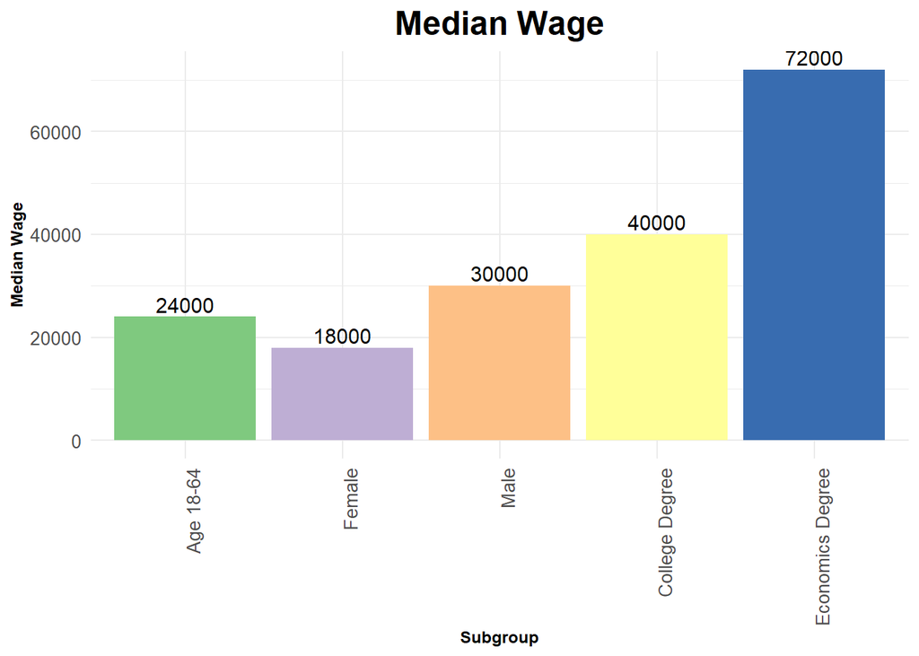

```r
library(RColorBrewer)
# Define custom x-axis labels
custom_x_labels <- c("Age 18-64", "Female", "Male", "College Degree", "Economics Degree")
# Creating the Bar Plot
  ggplot(result_table, aes(x = Name, y = Median, fill=Name)) +
  geom_col() +
  geom_text(aes(label = Median), vjust = -0.3, color = "black", size = 4) +
  scale_x_discrete(labels = custom_x_labels) +
  labs(x = "Subgroup", y = "Median Wage") +
  ggtitle("Median Wage") +
  theme_minimal() +
  theme(plot.title = element_text(size = 18, face = "bold",hjust = .5 ),
        axis.text.x = element_text(angle = 90, hjust = 1),
        axis.text = element_text(size = 10),
        axis.title = element_text(size = 9, face = "bold"),
        legend.position = "none")+
  scale_fill_brewer(palette = "Accent")
```

```r
# # Save the plot as a JPEG file
# ggsave("barplot.jpeg", plot = barplot, width = 8, height = 6, dpi = 300)
```

## Goal 4: Show the relationship between age and income for working-age individuals through a scatter plot

Here, I create a scatter plot showing the relationship between age and income for working-age individuals. The plot will further segment the data, differentiating between male and female categories. We will be able to visually comprehend the distinct age-income dynamics for each gender group.

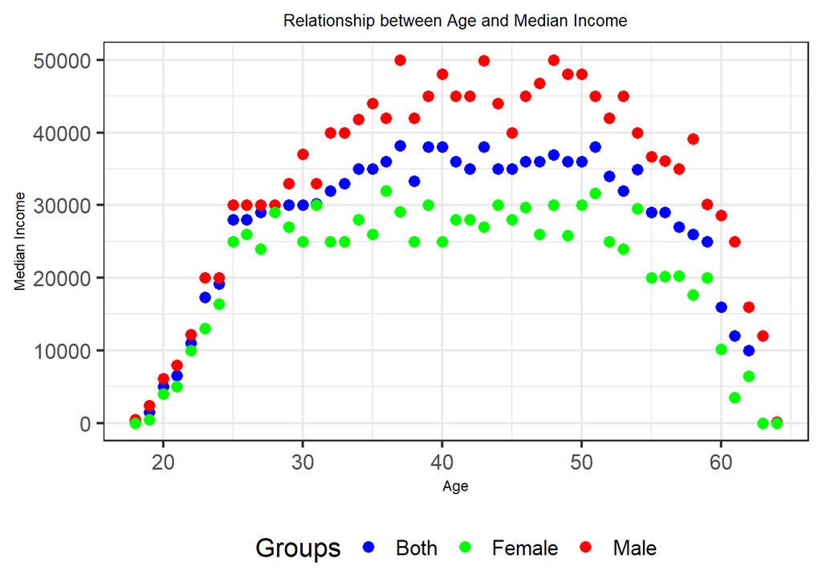

```r
# Creating the dataset
medianincome_by_age <- data %>% filter(AGEP >= 18 & AGEP <= 64) %>% group_by(AGEP) %>% summarize(Median = median(WAGP, na.rm = TRUE))
# Both Male and Female Median Income
medianincome_by_age <- data %>% filter(AGEP >= 18 & AGEP <= 64) %>% group_by(AGEP) %>% summarize(Median = median(WAGP, na.rm = TRUE))
medianincome_by_age$Group <- "Both"
## Male Median Income
medianincome_by_male <- data %>% filter(AGEP >= 18 & AGEP <= 64, SEX==1) %>% group_by(AGEP) %>% summarize(Median = median(WAGP, na.rm = TRUE))
medianincome_by_male$Group <- "Male"
## Female Median Income
medianincome_by_female <- data %>% filter(AGEP >= 18 & AGEP <= 64, SEX==2) %>% group_by(AGEP) %>% summarize(Median = median(WAGP, na.rm = TRUE))
medianincome_by_female$Group <- "Female"
# Scatter plot for the relationship between age and working age individual
  ggplot() + geom_point(data= medianincome_by_age, aes(x = AGEP, y = Median,col=Group),size=3) +
  geom_point(data=medianincome_by_male, aes(x = AGEP, y = Median,col=Group), size=3)+
    geom_point(data=medianincome_by_female, aes(x = AGEP, y = Median,col=Group), size=3)+
  labs(x="Age",y="Median Income", color="Groups")+
     scale_color_manual(values = c("Both" = "blue", "Male" = "red", "Female"="Green")) +
  ggtitle ("Relationship between Age and Median Income")+
  theme(plot.title = element_text(size=10, hjust = .5),
        axis.title = element_text(size=9),
        legend.position = "bottom")
```